# Predicting tumor subgroup in pseudobulk and single cells

Steven Foltz

2023

This notebook uses a medulloblastoma subgroup prediction model trained on bulk data to predict the subgroup of pseudobulk samples and individual cells from single-cell RNA-seq experiments. Pseudobulk samples were generated from single-cell experiments by averaging gene expression across all cells on a per gene level. Prediction models were trained using bulk gene expression data (bulk array and RNA-seq) in `analysis_notebooks/baseline_models.Rmd`. Here, we use the trained kTSP and random forest (RF) models to predict single cell subgroups from scRNA-seq data generated by [Hovestadt, et. al](https://www.nature.com/articles/s41586-019-1434-6).

# Setup

```r
set.seed(8222)

# Load libraries
source(here::here("utils/color_schemes.R"))
library(patchwork)

# Directories
processed_data_dir <- here::here("processed_data")
plots_dir <- here::here("plots")
plots_data_dir <- here::here(plots_dir, "data")

# Input files
pseudobulk_metadata_filepath <- here::here(processed_data_dir, "pseudobulk_metadata.tsv")
single_cell_plot_data_filepath <- here::here(plots_data_dir, "single_cell_test_predictions.tsv")
pseudobulk_plot_data_filepath <- here::here(plots_data_dir, "pseudobulk_test_predictions.tsv")

# Output plots
pseudobulk_subgroups_plot_filepath <- here::here(plots_dir, "single_cell_pseudobulk_subgroups.pdf")
percentage_subgroups_plot_filepath <- here::here(plots_dir, "single_cell_percentage_subgroups.pdf")
subgroup_umap_plot_filepath <- here::here(plots_dir, "single_cell_subgroup_umap.pdf")
confidence_plot_filepath <- here::here(plots_dir, "single_cell_confidence.pdf")
cluster_umap_plot_filepath <- here::here(plots_dir, "single_cell_cluster_umap.pdf")

combined_percentage_plot_filepath <- here::here(plots_dir, "single_cell_combined_percentage.pdf")
combined_umap_plot_filepath <- here::here(plots_dir, "single_cell_combined_umap.pdf")

# Read in data
pseudobulk_metadata_df <- readr::read_tsv(pseudobulk_metadata_filepath,
                                          show_col_types = FALSE) |>
  dplyr::mutate(sample_accession = title)

pseudobulk_plot_df <- readr::read_tsv(pseudobulk_plot_data_filepath,
                                      show_col_types = FALSE)

single_cell_plot_df <- readr::read_tsv(single_cell_plot_data_filepath,
                                       show_col_types = FALSE)

mb_subgroups <- c("G3", "G4", "SHH", "WNT")
```

# Plot pseudobulk subgroup predictions

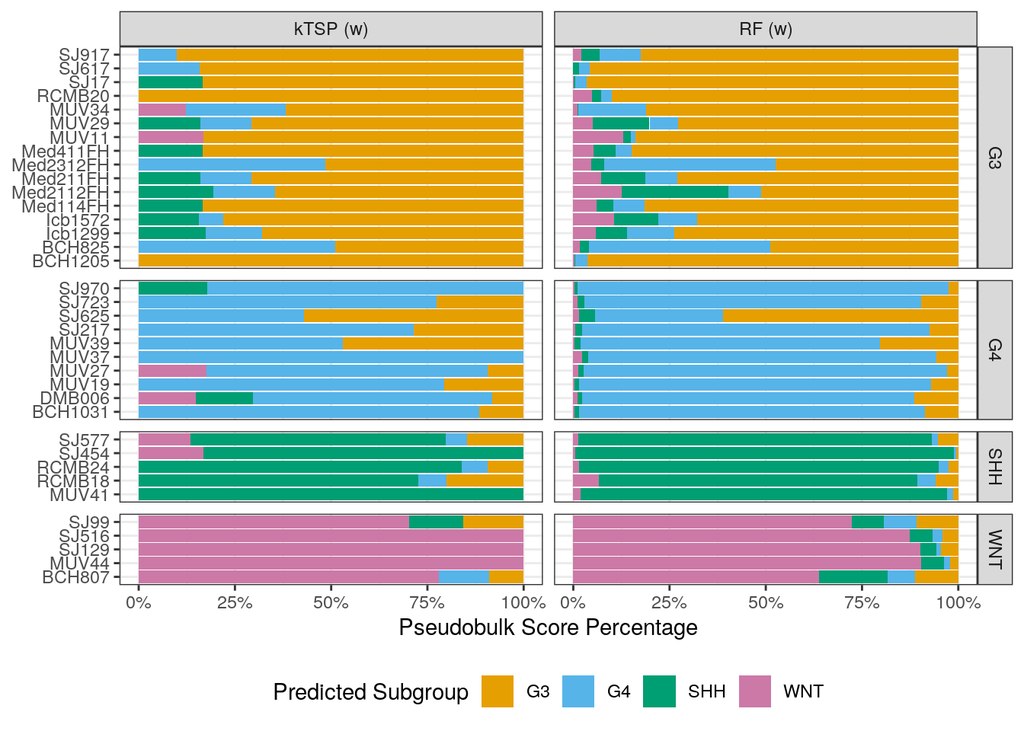

```r
pseudobulk_subgroups_plot_object <- pseudobulk_plot_df |>
  ggplot2::ggplot(ggplot2::aes(y = sample_accession,
                               x = value,
                               fill = predicted_subgroup)) +
  ggplot2::geom_col(position = "fill") +
  ggplot2::scale_x_continuous(labels = scales::percent) +
  ggplot2::facet_grid(rows = ggplot2::vars(subgroup),
                      cols = ggplot2::vars(model_type),
                      space = "free_y",
                      scales = "free_y") +
  ggplot2::scale_fill_manual(values = subgroup_colors) +
  ggplot2::labs(x = "Pseudobulk Score Percentage",
                y = NULL,
                fill = "Predicted Subgroup") +
  ggplot2::theme_bw() +
  ggplot2::theme(legend.position = "bottom",
                 legend.direction = "horizontal")

ggplot2::ggsave(filename = pseudobulk_subgroups_plot_filepath,
                plot = pseudobulk_subgroups_plot_object,
                width = 7.5,
                height = 6)

pseudobulk_subgroups_plot_object
```

### Mis-labeled samples

```r
pseudobulk_plot_df |>
  tidyr::pivot_wider(id_cols = c(sample_accession, subgroup),
                     names_from = c(model_type, predicted_subgroup),
                     values_from = value) |>
  dplyr::rowwise() |>
  dplyr::mutate(kTSP_pred = c("G3", "G4", "SHH", "WNT")[which.max(c(`kTSP (w)_G3`, `kTSP (w)_G4`, `kTSP (w)_SHH`, `kTSP (w)_WNT`))],
                RF_pred = c("G3", "G4", "SHH", "WNT")[which.max(c(`RF (w)_G3`, `RF (w)_G4`, `RF (w)_SHH`, `RF (w)_WNT`))]) |>
  dplyr::ungroup() |>
  dplyr::filter(subgroup != kTSP_pred | subgroup != RF_pred) |>
  dplyr::select(Sample = sample_accession,
                `Actual subgroup` = subgroup,
                `kTSP prediction` = kTSP_pred,
                `RF prediction` = RF_pred) |>
  knitr::kable()
```

| Sample | Actual subgroup | kTSP prediction | RF prediction |
| --- | --- | --- | --- |
| BCH825 | G3 | G4 | G3 |
| SJ625 | G4 | G3 | G3 |

### Comparison of pseudobulk kTSP vs. RF

- RF models tend to assign some likelihood to every subgroup (median of 4) while kTSP predictions are more frugal (median of 2)
- kTSP predicted only WNT in 3/5 WNT cases
- kTSP narrowly mixed up two G3/G4 cases (BCH825, SJ625) while RF missed only one (SJ625)

# Plot single cell subgroup predictions

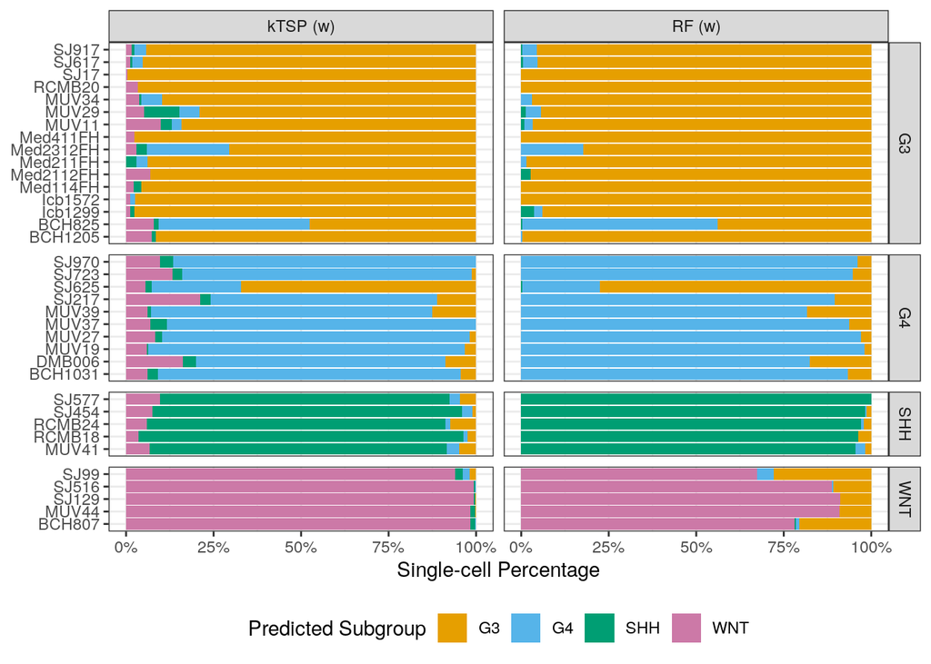

```r
percentage_subgroups_plot_object <- single_cell_plot_df |>
  dplyr::count(sample_accession, subgroup, predicted_labels, model_type) |>
  ggplot2::ggplot(ggplot2::aes(y = sample_accession,
                               x = n,
                               fill = predicted_labels)) +
  ggplot2::geom_col(position = ggplot2::position_fill()) +
  ggplot2::scale_x_continuous(labels = scales::percent) +
  ggplot2::facet_grid(rows = ggplot2::vars(subgroup),
                      cols = ggplot2::vars(model_type),
                      space = "free_y",
                      scales = "free_y") +
  ggplot2::scale_fill_manual(values = subgroup_colors) +
  ggplot2::labs(y = NULL,
                x = "Single-cell Percentage",
                fill = "Predicted Subgroup") +
  ggplot2::theme_bw() +
  ggplot2::theme(legend.position = "bottom")

ggplot2::ggsave(filename = percentage_subgroups_plot_filepath,
                plot = percentage_subgroups_plot_object,
                height = 10,
                width = 7.5)

percentage_subgroups_plot_object
```

### Comparison of single cell kTSP vs. RF

- Most samples show the same tumor subgroup predicted for most of their cells
- kTSP shows greater mixture of predicted subgroups in G3, G4, and SHH compared to RF, less mixture in WNT
- Three samples (“BCH825”, “Med2312FH”, “SJ625”) show largest degree of mixture of predicted subgroups (G3/G4)

# Plot confidence of subgroup predictions

### Prep plotting data

Three samples in particular are of interest given the mixture of subgroups predicted (“BCH825”, “Med2312FH”, “SJ625”).

```r
mixed_samples <- sort(c("BCH825", "Med2312FH", "SJ625"))

mixed_samples_with_subgroup <- pseudobulk_metadata_df |>
  dplyr::filter(sample_accession %in% mixed_samples) |>
  dplyr::mutate(sample_with_subgroup = stringr::str_c(title, " (", subgroup, ")")) |>
  dplyr::select(sample_accession, subgroup, sample_with_subgroup)
```

### Plot UMAPs with subgroup prediction

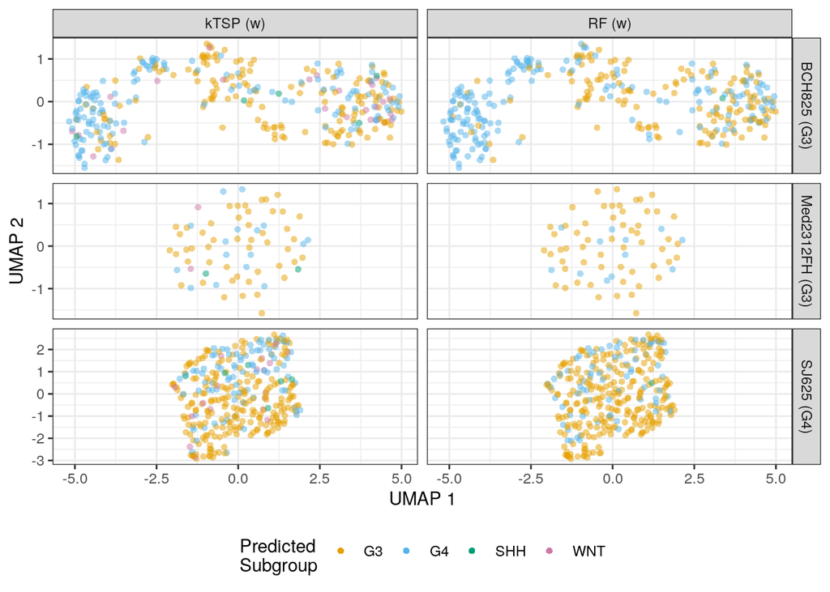

```r
subgroup_umap_plot_object <- single_cell_plot_df |>
  dplyr::filter(sample_accession %in% mixed_samples) |>
  dplyr::left_join(mixed_samples_with_subgroup,
                   by = "sample_accession") |>
  ggplot2::ggplot(ggplot2::aes(x = UMAP_1,
                               y = UMAP_2,
                               color = predicted_labels)) +
  ggplot2::geom_point(shape = 16,
                      alpha = 0.5) +
  ggplot2::scale_color_manual(values = subgroup_colors) +
  ggplot2::scale_alpha_continuous(range = c(0, 1)) +
  ggplot2::facet_grid(rows = ggplot2::vars(sample_with_subgroup),
                      cols = ggplot2::vars(model_type),
                      scales = "free") +
  ggplot2::labs(x = "UMAP 1",
                y = "UMAP 2",
                color = "Predicted\nSubgroup") +
  ggplot2::guides(colour = ggplot2::guide_legend(override.aes = list(alpha = 1))) +
  ggplot2::theme_bw() +
  ggplot2::theme(legend.position = "bottom",
                 legend.direction = "horizontal")

ggplot2::ggsave(filename = subgroup_umap_plot_filepath,
                plot = subgroup_umap_plot_object,
                width = 7.5,
                height = 6)

subgroup_umap_plot_object
```

### Plot UMAPs with assigned clusters

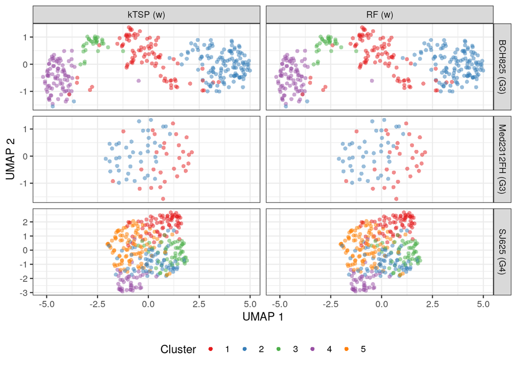

```r
cluster_umap_plot_object <- single_cell_plot_df |>
  dplyr::filter(sample_accession %in% mixed_samples) |>
  dplyr::left_join(mixed_samples_with_subgroup,
                   by = "sample_accession") |>
  ggplot2::ggplot(ggplot2::aes(x = UMAP_1,
                               y = UMAP_2,
                               color = factor(cluster))) +
  ggplot2::geom_point(shape = 16,
                      alpha = 0.5) +
  ggplot2::facet_grid(rows = ggplot2::vars(sample_with_subgroup),
                      cols = ggplot2::vars(model_type),
                      scales = "free") +
  ggplot2::scale_color_brewer(palette = "Set1") +
  ggplot2::labs(x = "UMAP 1",
                y = "UMAP 2",
                color = "Cluster") +
  ggplot2::guides(colour = ggplot2::guide_legend(override.aes = list(alpha = 1))) +
  ggplot2::theme_bw() +
  ggplot2::theme(legend.position = "bottom",
                 legend.direction = "horizontal")

ggplot2::ggsave(filename = cluster_umap_plot_filepath,
                plot = cluster_umap_plot_object,
                width = 7.5,
                height = 6)

cluster_umap_plot_object
```

### Plot confidence of individual cell predictions

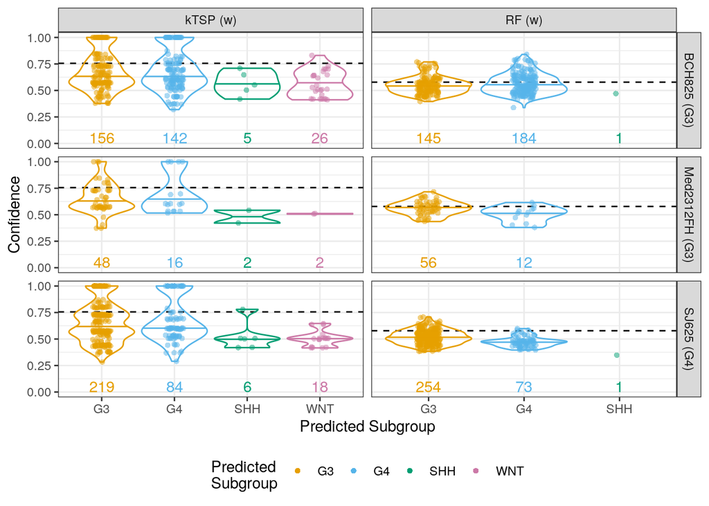

```r
typical_confidence_df <- single_cell_plot_df |>
  dplyr::filter(!is.na(confidence)) |>
  dplyr::group_by(sample_accession,
                  subgroup,
                  predicted_labels,
                  model_type) |>
  dplyr::summarize(median_confidence = median(confidence),
                   .groups = "drop") |>
  tidyr::pivot_wider(names_from = predicted_labels,
                     values_from = median_confidence) |>
  dplyr::rowwise() |>
  dplyr::mutate(subgroup_conf = c(G3, G4, SHH, WNT)[which(mb_subgroups == subgroup)]) |>
  dplyr::ungroup() |>
  dplyr::group_by(model_type) |>
  dplyr::summarize(median_subgroup_conf = median(subgroup_conf))

cell_counts_df <- single_cell_plot_df |>
  dplyr::filter(sample_accession %in% mixed_samples,
                !is.na(confidence)) |>
  dplyr::left_join(mixed_samples_with_subgroup,
                   by = "sample_accession") |>
  dplyr::count(sample_with_subgroup,
               model_type,
               predicted_labels)

confidence_plot_object <- single_cell_plot_df |>
  dplyr::filter(sample_accession %in% mixed_samples,
                !is.na(confidence)) |>
  dplyr::left_join(mixed_samples_with_subgroup,
                   by = "sample_accession") |>
  ggplot2::ggplot(ggplot2::aes(x = predicted_labels,
                               y = confidence,
                               color = predicted_labels)) +
  ggplot2::geom_hline(data = typical_confidence_df,
                      mapping = ggplot2::aes(yintercept = median_subgroup_conf),
                      lty = 2) +
  ggplot2::geom_violin(fill = NA,
                       draw_quantiles = 0.5,
                       position = ggplot2::position_dodge(width = 0.75), scale = "width",
                       show.legend = FALSE) +
  ggplot2::geom_point(shape = 16,
                      alpha = 0.5,
                      position = ggplot2::position_jitterdodge(jitter.height = 0,
                                                               jitter.width = 0.25)) +
  ggplot2::geom_text(data = cell_counts_df,
                     ggplot2::aes(label = n),
                     y = 0,
                     vjust = 0,
                     show.legend = FALSE) +
  ggplot2::facet_grid(rows = ggplot2::vars(sample_with_subgroup),
                      cols = ggplot2::vars(model_type),
                      scales = "free") +
  ggplot2::scale_color_manual(values = subgroup_colors) +
  ggplot2::scale_y_continuous(limits = c(0, NA)) +
  ggplot2::labs(x = "Predicted Subgroup",
                y = "Confidence",
                color = "Predicted\nSubgroup") +
  ggplot2::guides(colour = ggplot2::guide_legend(override.aes = list(alpha = 1))) +
  ggplot2::theme_bw() +
  ggplot2::theme(legend.position = "bottom",
                 legend.direction = "horizontal")

ggplot2::ggsave(filename = confidence_plot_filepath,
                plot = confidence_plot_object,
                width = 7.5, height = 6)
confidence_plot_object
```

- Cell subgroup predictions are more confident when subgroup predictions are consistent across entire sample.
- The relative confidence levels of each cell’s prediction show that predictions in samples with one dominant subgroup are more confident than in samples with mixed subgroup predictions (BCH825, Med2312FH, SJ625).
- While some cells from mixed subgroup samples show high confidence as G3 or G4, most show that cells receive signals from both G3 and G4 rules, meaning they have an intermediate phenotype, rather than being a mixture of true G3 and true G4 cells.

### G3 and G4 prediction confidence exists on a G3-G4 spectrum

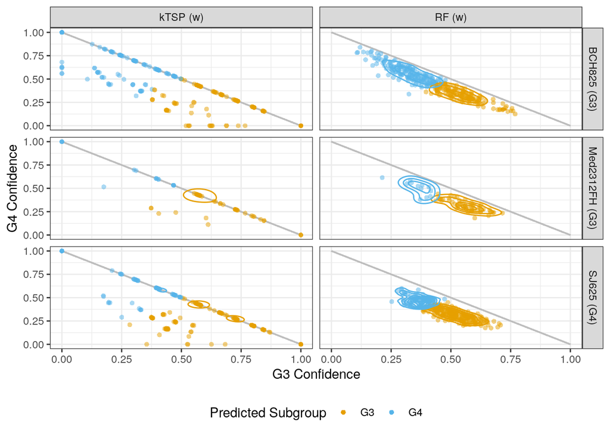

```r
joint_G3_G4_df <- single_cell_plot_df |>
  dplyr::filter(sample_accession %in% mixed_samples,
                !is.na(confidence)) |>
  dplyr::left_join(mixed_samples_with_subgroup,
                   by = "sample_accession") |>
  dplyr::filter(predicted_labels %in% c("G3", "G4"))

# what percentage of cells have no contribution from SHH or WNT (G3 and G4 only)
diagonal_pct_list <- joint_G3_G4_df |>
  split(joint_G3_G4_df$model_type) |>
  purrr::map(\(x) mean(x$SHH == 0 & x$WNT == 0)*100)

joint_G3_G4_confidence_plot_object <- joint_G3_G4_df |>
  ggplot2::ggplot(ggplot2::aes(x = G3/total,
                               y = G4/total,
                               color = predicted_labels)) +
  ggplot2::geom_segment(x = 0, xend = 1,
                        y = 1, yend = 0,
                        color = "grey",
                        lty = 1) +
  ggplot2::geom_point(shape = 16,
                      alpha = 0.5) +
  ggplot2::geom_density_2d(show.legend = FALSE) +
  ggplot2::facet_grid(rows = ggplot2::vars(sample_with_subgroup),
                      cols = ggplot2::vars(model_type),
                      scales = "free") +
  ggplot2::scale_color_manual(values = subgroup_colors) +
  ggplot2::scale_x_continuous(limits = c(0,1)) +
  ggplot2::scale_y_continuous(limits = c(0,1)) +
  ggplot2::labs(x = "G3 Confidence",
                y = "G4 Confidence",
                color = "Predicted Subgroup") +
  ggplot2::guides(colour = ggplot2::guide_legend(override.aes = list(alpha = 1))) +
  ggplot2::theme_bw() +
  ggplot2::theme(legend.position = "bottom",
                 legend.direction = "horizontal")

joint_G3_G4_confidence_plot_object
```

- Prediction confidence of G3 and G4 cells forms a spectrum between poles at 100% G3 and 100% G4.
- For kTSP (w), some cells have some score contributed from other subgroups, but most (77.4%) are on the diagonal.

# Combined plots

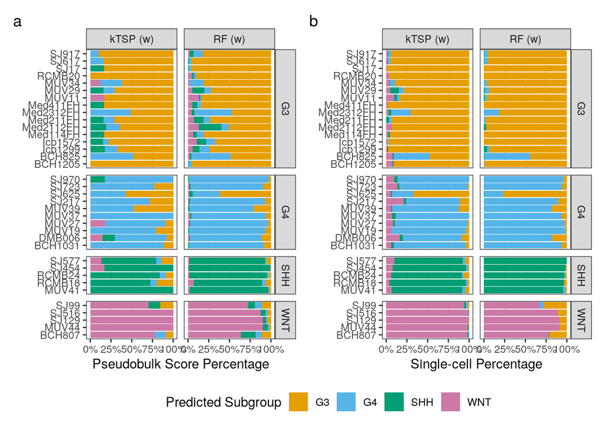

```r
combined_percentage_plot_object <- pseudobulk_subgroups_plot_object + percentage_subgroups_plot_object +
  patchwork::plot_layout(guides = "collect") +
  patchwork::plot_annotation(tag_levels = 'a') &
  ggplot2::theme(legend.position = "bottom")

ggplot2::ggsave(filename = combined_percentage_plot_filepath,
                plot = combined_percentage_plot_object,
                width = 7.5,
                height = 6)

combined_percentage_plot_object
```

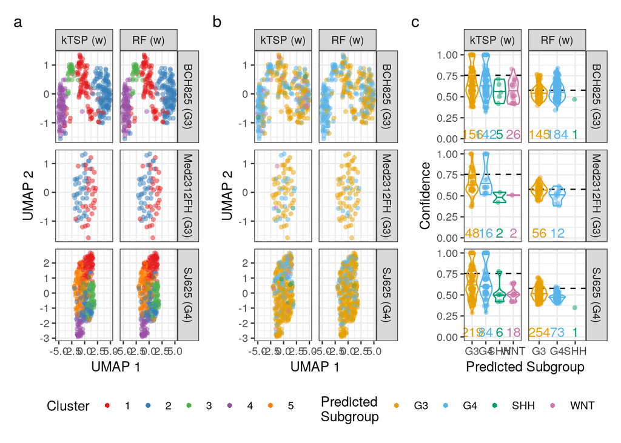

```r
combined_umap_plot_object <- cluster_umap_plot_object + subgroup_umap_plot_object + confidence_plot_object +
  patchwork::plot_annotation(tag_levels = 'a') +
  patchwork::plot_layout(guides = "collect") &
  ggplot2::theme(legend.position = "bottom")

ggplot2::ggsave(filename = combined_umap_plot_filepath,
                plot = combined_umap_plot_object,
                width = 7.5,
                height = 6)
combined_umap_plot_object
```